# Predicting a pandemic

## A global pandemic

[figure not shown]

## Talk outline

- What is COVID-19?
- Why is it spreading so fast?
- How do we predict the consequences of the disease?
- How do we tell if our predictions are likely to be accurate?
- How can we slow and stop the spread of the COVID-19?

## What is COVID-19?

## What is COVID-19?

### Defining some terms

- **COVID-19** is a disease (short for coronavirus disease 2019)
- **SARS-CoV-2** is the virus that causes COVID-19 (short for severe acute respiratory syndrome coronavirus 2)
- **Coronavirus** is a general name for the group of viruses that include SARS-CoV-2.

Find out more about the naming of COVID-19 here

## SARS-CoV-2 is a virus

[figure not shown]

Image credit: Alissa Eckert, Dan Higgins, https://commons.wikimedia.org/w/index.php?curid=86444014

## SARS-CoV-2 is a virus

- A positive-sense single-stranded RNA virus
- Closest relative is a virus found in bats
- May have passed through an intermediate host (e.g. pangolins) before being transmitted to humans, but not yet clear

[figure not shown]

Image credit: Alissa Eckert, Dan Higgins, https://commons.wikimedia.org/w/index.php?curid=86444014

## COVID-19 is a disease

- Incubation period typically 5-6 days, but may be shorter or longer
- Symptoms include fever, cough and difficulties with breathing
- In many cases symptoms are mild or absent
- But in others can lead to pneumonia, organ failure and death

## Testing for COVID-19

Two main approaches:

- Look for the virus (RT-PCR)
- Look for an immune response to the virus (serological testing)
- RT-PCR approach is well established, whereas serological testing still in development

## Why is COVID-19 spreading so fast?

## Why is COVID-19 spreading so fast?

[figure not shown]

## Why is COVID-19 spreading so fast?

### Exponential growth

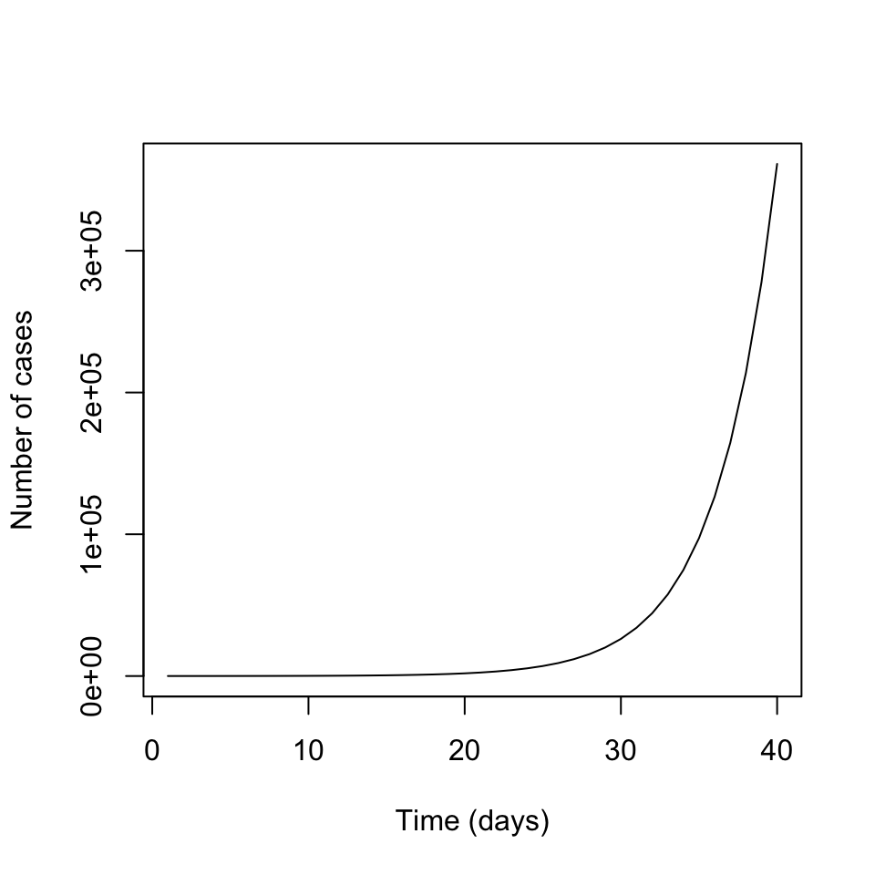

## Why is COVID-19 spreading so fast?

### Exponential growth

- Growth where the amount being added is proportional to the amount already present (e.g. Doubling over time)
- \(x_t = x_0(1+r)^t\)
- Where *r* is the growth rate and *t* is time

## Why is COVID-19 spreading so fast?

### Exponential growth

https://www.washingtonpost.com/graphics/2020/world/corona-simulator/

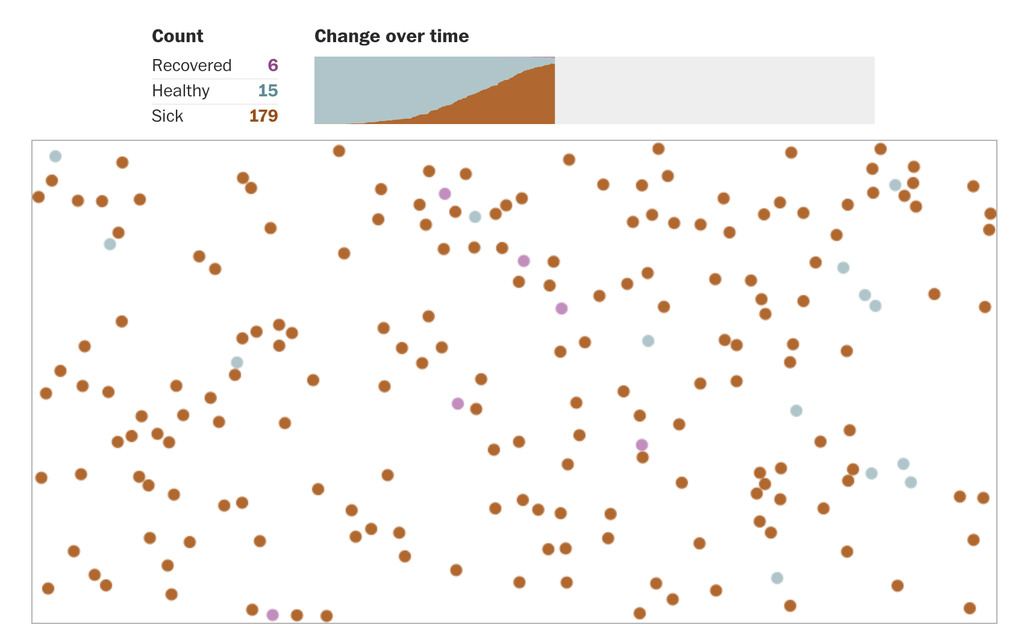

## How do we predict the consequences of the disease?

## How do we predict the consequences of the disease?

### What do we want to predict?

- The number of people infected
- The number of people with symptoms
- The number of deaths
- The ability of healthcare systems to cope

## How do we predict the consequences of the disease?

### Building a model

- What is the transmission potential of the disease?
- What proportion of infected people show mild/severe symptoms?
- What is the fatality rate?
- What is the capacity of a given healthcare system?

## How do we predict the consequences of the disease?

### Building a model

What is the transmission potential of the disease?

- How easily the virus is transmitted
- Rate of contact in a population
- Duration of infection
- The proprtion of susceptible individuals in a population

## How do we predict the consequences of the disease?

### What is the transmission potential of the disease?

- \(R_0\) is the *Basic reproduction number*
- The average number of people who will catch the disease from a single infected person, in a population where everyone is susceptible
- Encapsulates mode of transmission, contact rates, duration of infection.

## How do we predict the consequences of the disease?

### What is the transmission potential of the disease?

- \(R_0\) is an average, so summarises a distribution. This distribution is important.
- \(R_0\) can change depending on context (e.g. behaviour). This is very important.
- \(R_0\) is difficult to estimate, so different researchers can come up with different estimates. This is very very important.

## How do we predict the consequences of the disease?

### What is the transmission potential of the disease?

[figure not shown]

https://www.theatlantic.com/science/archive/2020/01/how-fast-and-far-will-new-coronavirus-spread/605632/

## How do we predict the consequences of the disease?

### Building a model

- What proportion of people show symptoms?
- Severe symptoms?
- Fatality rates?